# 3 R中的回归分析之二：回归结果的报告和残差的图形诊断

# 4 本章作业

**将代码和输出结果转成图片，上传至91速课平台。**

## 4.1 习题 一

**教材P94, 4.14,数据Table 4_7.xls**, 完成以下要求:

1.1 报告表4-7中所有变量的均值、标准差、中位数、最大值和最小值。

1.2 绘制CM和FLR的散点图，添加回归线，并在图中标注估计的一元回归方程的表达式；绘制CM和PGN的散点图，添加回归线，并在图中标注估计的一元回归方程的表达式；绘制CM和TFR的散点图，添加回归线，并在图中标注估计的一元回归方程的表达式。

1.3 以下述表格的形式报告下列三个模型的估计结果。

- Model1: CM和FLR的一元回归模型。
- Model2: CM和FLR、PGN的二元回归模型。
- Model3: CM和FLR、PGN、TFR的一元线性回归模型。

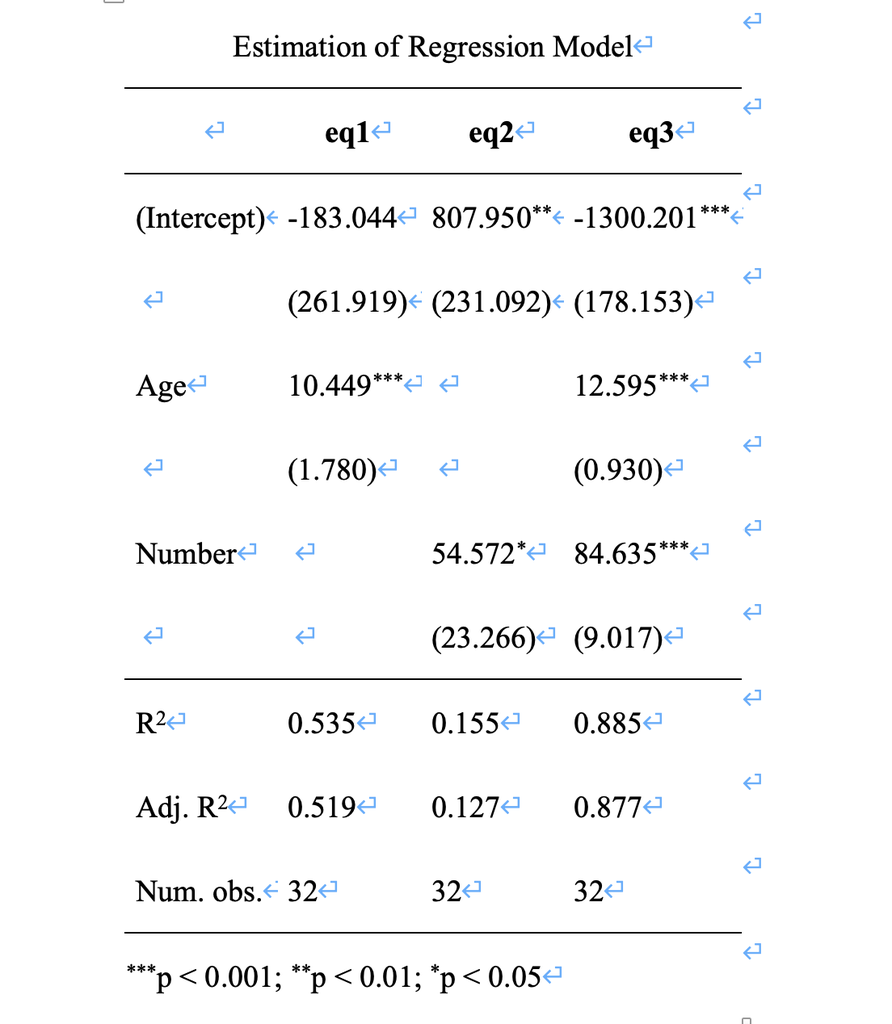

1.4 报告1.3中三个回归模型的方差分析表（提示：anova()函数）。

1.5 运用F检验讨论模型1和模型3，模型3中的PGN、TFR是否是多余的解释变量？

1.6 对模型3进行残差的图形诊断和正态性检验。

## 4.2 习题二

数据：starwars {dplyr}。加载dplyr包，调用数据集starwars， 完成以下要求:

2.1 starwars中有多少个个案，多少个变量？哪些变量是定量变量？

2.2 starwars中有多少个个案在14个变量上都没有缺失值？

2.3 将starwars中的name, height, mass, sex, species提取出来，保存为一个数据框，将其命名为data1，在该数据框中在前述5个变量中都没有缺失值的个案一共有多少个？

2.4 在data1中追加一个新的变量BMI，BMI等于体重（千克）除以身高（米）的平方， BMI最高者和最低者的name, height, mass, sex列示出来。

2.5 在data1中追加一个新的变量size, 若BMI的值大于30，则size等于”large”, 若BMI的值小于20，则size等于”small”,BMI的值若大于等于20且小于等于30的，其size等于medium。

2.6 对data1中的个案进行筛选，将height大于180、sex等于male的个案保存到数据框data2中，data2有多少个个案？

2.7 对data1中的个案进行筛选，将height小于100或者mass小于60的个案保存到数据框data3中，data3有多少个个案？